# Meta Analysis

#### **Library**

```r
library(meta)
```

#### 0. 코드 적어보기.

```r
data(Fleiss93)
metabin(event.e, n.e, event.c, n.c, studlab=paste(study, year), sm="OR",
        method="inverse", data=Fleiss93)
```

```
##                 OR           95%-CI %W(fixed) %W(random)
## MRC-1 1974  0.7197 [0.4890; 1.0593]       2.8        8.2
## CDP 1976    0.6808 [0.4574; 1.0132]       2.7        7.8
## MRC-2 1979  0.8029 [0.6065; 1.0629]       5.4       13.2
## GASP 1979   0.8007 [0.4863; 1.3186]       1.7        5.4
## PARIS 1980  0.7981 [0.5526; 1.1529]       3.1        8.9
## AMIS 1980   1.1327 [0.9347; 1.3728]      11.4       20.7
## ISIS-2 1988 0.8950 [0.8294; 0.9657]      72.9       35.8
##
## Number of studies combined: k = 7
##
##                          OR           95%-CI     z p-value
## Fixed effect model   0.8969 [0.8405; 0.9571] -3.28  0.0010
## Random effects model 0.8763 [0.7743; 0.9917] -2.09  0.0365
##
## Quantifying heterogeneity:
## tau^2 = 0.0096; H = 1.29 [1.00; 1.99]; I^2 = 39.7% [0.0%; 74.6%]
##
## Test of heterogeneity:
##     Q d.f. p-value
##  9.95    6  0.1269
##
## Details on meta-analytical method:
## - Inverse variance method
## - DerSimonian-Laird estimator for tau^2
```

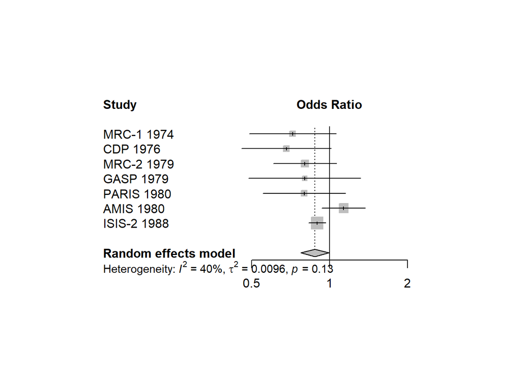

```r
meta.1 <- metabin(event.e, n.e, event.c, n.c, studlab=paste(study, year), sm="OR",
                  method="inverse", data=Fleiss93)
forest(meta.1, comb.fixed = FALSE, leftcols = "studlab", rightcols = FALSE)
```

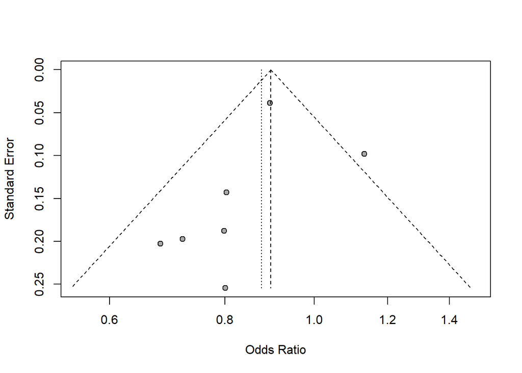

```r
funnel(meta.1)
```

```r
data(Fleiss93cont)
metacont(n.e, mean.e, sd.e, n.c, mean.c, sd.c, sm="SMD", data=Fleiss93cont)
```

```
##       SMD             95%-CI %W(fixed) %W(random)
## 1 -0.3399 [-1.1152;  0.4354]      11.5       11.5
## 2 -0.5659 [-1.0274; -0.1044]      32.6       32.6
## 3 -0.2999 [-0.7712;  0.1714]      31.2       31.2
## 4  0.1250 [-0.4954;  0.7455]      18.0       18.0
## 5 -0.7346 [-1.7575;  0.2883]       6.6        6.6
##
## Number of studies combined: k = 5
##
##                          SMD             95%-CI     z p-value
## Fixed effect model   -0.3434 [-0.6068; -0.0800] -2.56  0.0106
## Random effects model -0.3434 [-0.6068; -0.0800] -2.56  0.0106
##
## Quantifying heterogeneity:
## tau^2 = 0; H = 1.00 [1.00; 2.10]; I^2 = 0.0% [0.0%; 77.4%]
##
## Test of heterogeneity:
##     Q d.f. p-value
##  3.68    4  0.4515
##
## Details on meta-analytical method:
## - Inverse variance method
## - DerSimonian-Laird estimator for tau^2
## - Hedges' g (bias corrected standardised mean difference)
```

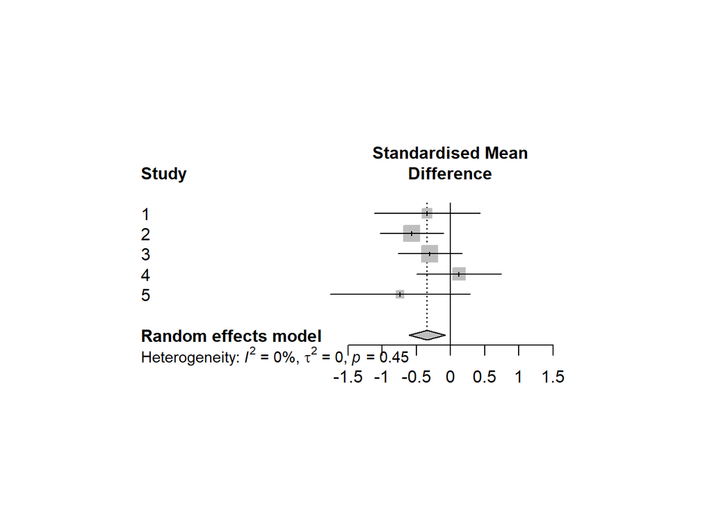

```r
meta.2 <- metacont(n.e, mean.e, sd.e, n.c, mean.c, sd.c, sm="SMD", data=Fleiss93cont)
forest(meta.2, comb.fixed=FALSE, leftcols="studlab", rightcol=FALSE)
```

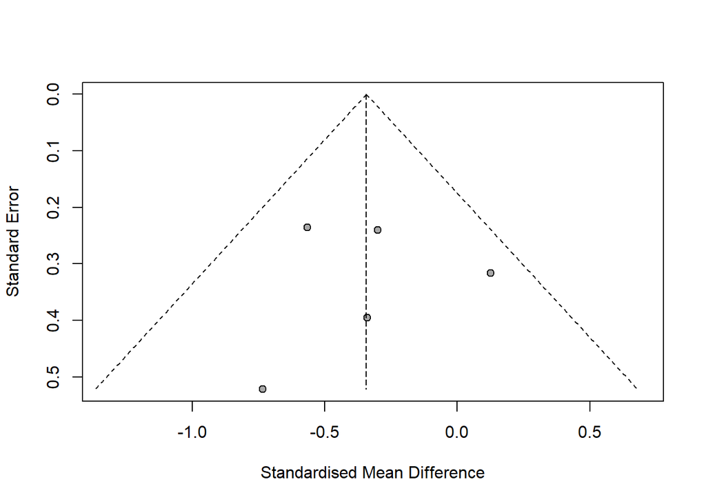

```r
funnel(meta.2)
```

#### 1. ’비율 비교’의 메타 연구에서 Mantel-Haenszel방법과 Peto의 방법은 무엇인가? Fleiss93 자료에 적용하는 경우, 역분산법의 결과와 얼마나 다른가?

Mentel-Haenszel방법과 Peto방법 모두 사건비율과 같은 이산형 자료연구에서 자주쓰이는 메타분석방법이다. 위의 두 방법의 차이는 아래와 같다.

1). Mantel-Haenszel방법  
여러개의 분할표로부터 데이터를 결합하는 방법이다. 기본은 2 X 2의 분할표의 경우에서 출발한다. 표본수가 작은 연구라 할지라도 그러한 연구의 수가 많을 때 효과적인 방법이며, Meta분석에서 고정효과방법의 기본적인 방법이다. OR, RR, RD 중 어느 효과를 쓰는지에 따라 가중치를 주는 방식이 달라진다. 특히 event 수가 적은 경우에 역분산방법보다 선호되는 방법이다.

2). Peto방법  
여러개의 분할표로부터 데이터를 결합하기 위한 Mantel-Haenszel 방법을 수정한 것이다. 기본은 2 X 2 의 분할표의 경우에서 출발한다. 그리고 각 연구로부터 얻은 오즈비의 추정치와 그 추정치의 표준오차를 결합하는 것으로 구해진다. event 수가 적은 연구들을 결합하는 경우, 혹은 처리군이나 대조군 중 하나에서 결과가 발생하지 않는 연구들이 있는 경우에 가장 적절한 메타분석 방법이며 계산하기가 쉽다. 그러나 두 처리집단 간 표본수에 불균형이 심한 연구들이 많으면 bias된 OR값 및 표준오차를 제공하고, OR의 참값이 큰 경우에는 과소추정한다는 단점을 가지고 있다.

```r
# 1-1. MH
metabin(event.e, n.e, event.c, n.c, studlab=paste(study, year), sm="OR",
        method="MH", data=Fleiss93)
```

```
##                 OR           95%-CI %W(fixed) %W(random)
## MRC-1 1974  0.7197 [0.4890; 1.0593]       3.2        8.2
## CDP 1976    0.6808 [0.4574; 1.0132]       3.1        7.8
## MRC-2 1979  0.8029 [0.6065; 1.0629]       5.7       13.2
## GASP 1979   0.8007 [0.4863; 1.3186]       1.8        5.4
## PARIS 1980  0.7981 [0.5526; 1.1529]       3.2        8.9
## AMIS 1980   1.1327 [0.9347; 1.3728]      10.2       20.7
## ISIS-2 1988 0.8950 [0.8294; 0.9657]      72.9       35.8
##
## Number of studies combined: k = 7
##
##                          OR           95%-CI     z p-value
## Fixed effect model   0.8969 [0.8405; 0.9570] -3.29  0.0010
## Random effects model 0.8763 [0.7743; 0.9917] -2.09  0.0365
##
## Quantifying heterogeneity:
## tau^2 = 0.0096; H = 1.29 [1.00; 1.99]; I^2 = 39.7% [0.0%; 74.6%]
##
## Test of heterogeneity:
##     Q d.f. p-value
##  9.95    6  0.1269
##
## Details on meta-analytical method:
## - Mantel-Haenszel method
## - DerSimonian-Laird estimator for tau^2
```

```r
# 1-2. Peto
metabin(event.e, n.e, event.c, n.c, studlab=paste(study, year), sm="OR",
        method="Peto", data=Fleiss93)
```

```
##                 OR           95%-CI %W(fixed) %W(random)
## MRC-1 1974  0.7217 [0.4925; 1.0576]       2.9        8.4
## CDP 1976    0.6839 [0.4625; 1.0112]       2.8        8.0
## MRC-2 1979  0.8036 [0.6079; 1.0623]       5.4       13.3
## GASP 1979   0.8013 [0.4876; 1.3169]       1.7        5.4
## PARIS 1980  0.7935 [0.5444; 1.1566]       3.0        8.5
## AMIS 1980   1.1326 [0.9348; 1.3721]      11.4       20.7
## ISIS-2 1988 0.8950 [0.8295; 0.9657]      72.9       35.7
##
## Number of studies combined: k = 7
##
##                          OR           95%-CI     z p-value
## Fixed effect model   0.8968 [0.8405; 0.9570] -3.29  0.0010
## Random effects model 0.8760 [0.7741; 0.9913] -2.10  0.0359
##
## Quantifying heterogeneity:
## tau^2 = 0.0097; H = 1.29 [1.00; 1.99]; I^2 = 39.8% [0.0%; 74.7%]
##
## Test of heterogeneity:
##     Q d.f. p-value
##  9.97    6  0.1260
##
## Details on meta-analytical method:
## - Peto method
## - DerSimonian-Laird estimator for tau^2
```

위의 결과를 살펴보면 각 논문의 가중치 추정량, OR값, tau^2추정량, Q통계량 등이 미미하게 다름을 확인할 수 있다.

#### 2. Trim-and-Fill 방법이란 무엇인가?

깔때기 그림의 비대칭성을 보정하여 수집된 메타자료에 내재된 출간편향을 제거한다. Trim-and-Fill방법은 다음의 절차를 따른다.  
(1) 비대칭을 유발하는 표본수가 작은 연구들을 제거한다.  
(2) 이렇게 걸러진 연구들로 깔때기 그림의 중심을 재추정한다.  
(3) 생략된 연구와 중심을 기준으로 대조되는 연구들을 대체하여 끼워넣는다.

메타분석을 위해 수집된 개별연구들은 정상적 연구들과 다를 가능성이 있으므로, 이를 배제하기위해 반드시 필요한 작업이다.